# Ficha de Información Metropolitana

Martínez Rodriguez, Alvaro; Pérez Victorino, Leonardo

4 de abril de 2023

La ficha de información metropolitana es un recurso valioso para la planificación territorial en zonas metropolitanas. En ella se incluyen datos censales en diversos formatos, como gráficas, tablas y mapas provenientes principalmente de los censos económicos de los años 1999, 2004, 2009, 2014 y 2019. A su vez, también incluye información de los censos de población y vivienda del año 2020, ambos censos son publicados por el Instituto Nacional de Estadística y Geografía (INEGI).

# Ficha básica de la Zona Metropolitana de `Aguascalientes`

A continuación se presentan los datos sociodemograficos principales de la zona metropolitana de `Aguascalientes` con la clave`1.01`.

- La zona se compone de un total de `3` municipios, los cuales son:

| Nombre | Clave |
| --- | --- |
| Aguascalientes | 01001 |
| Jesús María | 01005 |
| San Francisco de los Romo | 01011 |

Municipios de la zona metropolitana

[interactive chart not shown]

##### Composición, estructura y distribución de la población

La zona metropolitana de `Aguascalientes` tiene una pobalción de `1,140,916` de habitantes, según el Censo de Población y Vivienda 2020. La composición de la población se describe en los siguientes puntos:

- Población total respecto al país: `1%`
- Población Masculina: `49%`
- Población Femenina: `51%`
- Relación M-F: `96.9166667`
- Grado promedio de escolaridad: `10.09`
- Densisad poblacional `632.426290028436`

[interactive chart not shown]

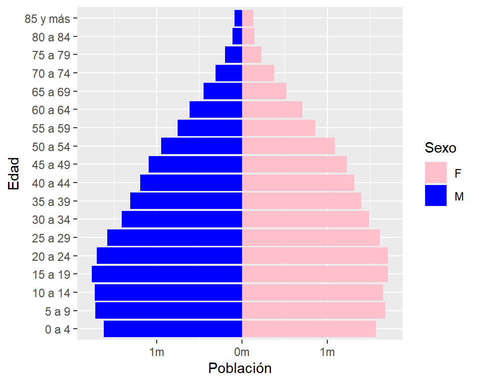